# Adult Census Income

Michihito Mitsuyasu

2019/4/15

## library

```r
library(tidyverse)
library(caret)
library(randomForest)
library(ggridges)
library(rpart)
library(partykit)
```

## Executive summary section

### describes the dataset

This data was extracted from the 1994 Census bureau database by Ronny Kohavi and Barry Becker (Data Mining and Visualization, Silicon Graphics). A set of reasonably clean records was extracted using the following conditions: ((AAGE>16) && (AGI>100) && (AFNLWGT>1) && (HRSWK>0)).

The prediction task is to determine whether a person makes over $50K a year.

https://www.kaggle.com/uciml/adult-census-income/activity

#### Description of fnlwgt (final weight)

The weights on the Current Population Survey (CPS) files are controlled to independent estimates of the civilian noninstitutional population of the US. These are prepared monthly for us by Population Division here at the Census Bureau. We use 3 sets of controls. These are:

A single cell estimate of the population 16+ for each state.

Controls for Hispanic Origin by age and sex.

Controls by Race, age and sex.

We use all three sets of controls in our weighting program and “rake” through them 6 times so that by the end we come back to all the controls we used. The term estimate refers to population totals derived from CPS by creating “weighted tallies” of any specified socio-economic characteristics of the population. People with similar demographic characteristics should have similar weights. There is one important caveat to remember about this statement. That is that since the CPS sample is actually a collection of 51 state samples, each with its own probability of selection, the statement only applies within state.

#### About this file

About this file Attributes:

> 50K, <=50K

age: continuous

workclass: Private, Self-emp-not-inc, Self-emp-inc, Federal-gov, Local-gov, State-gov, Without-pay, Never-worked

fnlwgt: continuous

education: Bachelors, Some-college, 11th, HS-grad, Prof-school, Assoc-acdm, Assoc-voc, 9th, 7th-8th, 12th, Masters, 1st-4th, 10th, Doctorate, 5th-6th, Preschool

education-num: continuous

marital-status: Married-civ-spouse, Divorced, Never-married, Separated, Widowed, Married-spouse-absent, Married-AF-spouse

occupation: Tech-support, Craft-repair, Other-service, Sales, Exec-managerial, Prof-specialty, Handlers-cleaners, Machine-op-inspct, Adm-clerical, Farming-fishing, Transport-moving, Priv-house-serv, Protective-serv, Armed-Forces

relationship: Wife, Own-child, Husband, Not-in-family, Other-relative, Unmarried

race: White, Asian-Pac-Islander, Amer-Indian-Eskimo, Other, Black

sex: Female, Male

capital-gain: continuous

capital-loss: continuous

hours-per-week: continuous

native-country: United-States, Cambodia, England, Puerto-Rico, Canada, Germany, Outlying-US(Guam-USVI-etc), India, Japan, Greece, South, China, Cuba, Iran, Honduras, Philippines, Italy, Poland, Jamaica, Vietnam, Mexico, Portugal, Ireland, France, Dominican-Republic, Laos, Ecuador, Taiwan, Haiti, Columbia, Hungary, Guatemala, Nicaragua, Scotland, Thailand, Yugoslavia, El-Salvador, Trinadad&Tobago, Peru, Hong, Holand-Netherlands

### train set and test set

I will create the trani set and the test set.

The train set is used to develop my algorithm.

The test set is used to evaluate how close your predictions are to the true values.

### The goal of the project

The prediction task is to use a test set to determine whether a person makes over $50K a year.

The predictions will be compared to the true ratings in the test set using accuracy.

### Key steps that were performed

1. Describes the adult dataset
2. Data exploration and visualization
3. Generate the train set and the test set
4. Comparison of CART and Random Forests
   1. CART
   2. Random Forests

## Methods section

### describes the adult dataset

I use the following code to generate the adult set.

```r
#create adult dataset
adult <- read_csv("https://github.com/mitti1210/edx-Choose_Your_Own/blob/master/adult.csv?raw=true")
```

```r
adult %>%
  select_if(is.character) %>%
  map(., ~ levels(factor(.x)))
```

```
## $workclass
## [1] "?"                "Federal-gov"      "Local-gov"
## [4] "Never-worked"     "Private"          "Self-emp-inc"
## [7] "Self-emp-not-inc" "State-gov"        "Without-pay"
##
## $education
##  [1] "10th"         "11th"         "12th"         "1st-4th"
##  [5] "5th-6th"      "7th-8th"      "9th"          "Assoc-acdm"
##  [9] "Assoc-voc"    "Bachelors"    "Doctorate"    "HS-grad"
## [13] "Masters"      "Preschool"    "Prof-school"  "Some-college"
##
## $marital.status
## [1] "Divorced"              "Married-AF-spouse"     "Married-civ-spouse"
## [4] "Married-spouse-absent" "Never-married"         "Separated"
## [7] "Widowed"
```

[output cut: 44 more lines]

```r
#String processing was performed because "?", "NA", and "-" were used. I changed income to 0,1.

adult <-
  adult %>%
  mutate_if(is_character, funs(str_replace_all(., pattern = "\\-", "_"))) %>%
  mutate_if(is_character, funs(str_replace_all(., pattern = "\\&", "_"))) %>%
  mutate_if(is_character, funs(str_replace_all(., pattern = "\\?", "NA"))) %>%
  mutate_if(is_character, as.factor) %>%
  mutate(income = as.factor(ifelse(income %in% ">50K", "1", "0")))
head(adult)
```

| age | workclass | fnlwgt | education | education.num | marital.status | occupation | relationship | race | sex | capital.gain | capital.loss | hours.per.week | native.country | income |
| --- | --- | --- | --- | --- | --- | --- | --- | --- | --- | --- | --- | --- | --- | --- |
| 90 | NA | 77053 | HS_grad | 9 | Widowed | NA | Not_in_family | White | Female | 0 | 4356 | 40 | United_States | 0 |
| 82 | Private | 132870 | HS_grad | 9 | Widowed | Exec_managerial | Not_in_family | White | Female | 0 | 4356 | 18 | United_States | 0 |
| 66 | NA | 186061 | Some_college | 10 | Widowed | NA | Unmarried | Black | Female | 0 | 4356 | 40 | United_States | 0 |
| 54 | Private | 140359 | 7th_8th | 4 | Divorced | Machine_op_inspct | Unmarried | White | Female | 0 | 3900 | 40 | United_States | 0 |
| 41 | Private | 264663 | Some_college | 10 | Separated | Prof_specialty | Own_child | White | Female | 0 | 3900 | 40 | United_States | 0 |
| 34 | Private | 216864 | HS_grad | 9 | Divorced | Other_service | Unmarried | White | Female | 0 | 3770 | 45 | United_States | 0 |

### Data exploration and visualization

#### Exploration

```r
str(adult)
```

```
## Classes 'spec_tbl_df', 'tbl_df', 'tbl' and 'data.frame': 32561 obs. of  15 variables:
##  $ age           : num  90 82 66 54 41 34 38 74 68 41 ...
##  $ workclass     : Factor w/ 9 levels "Federal_gov",..: 3 5 3 5 5 5 5 8 1 5 ...
##  $ fnlwgt        : num  77053 132870 186061 140359 264663 ...
##  $ education     : Factor w/ 16 levels "10th","11th",..: 12 12 16 6 16 12 1 11 12 16 ...
##  $ education.num : num  9 9 10 4 10 9 6 16 9 10 ...
##  $ marital.status: Factor w/ 7 levels "Divorced","Married_AF_spouse",..: 7 7 7 1 6 1 6 5 1 5 ...
##  $ occupation    : Factor w/ 15 levels "Adm_clerical",..: 8 4 8 7 11 9 1 11 11 3 ...
##  $ relationship  : Factor w/ 6 levels "Husband","Not_in_family",..: 2 2 5 5 4 5 5 3 2 5 ...
##  $ race          : Factor w/ 5 levels "Amer_Indian_Eskimo",..: 5 5 3 5 5 5 5 5 5 5 ...
##  $ sex           : Factor w/ 2 levels "Female","Male": 1 1 1 1 1 1 2 1 1 2 ...
##  $ capital.gain  : num  0 0 0 0 0 0 0 0 0 0 ...
##  $ capital.loss  : num  4356 4356 4356 3900 3900 ...
##  $ hours.per.week: num  40 18 40 40 40 45 40 20 40 60 ...
##  $ native.country: Factor w/ 42 levels "Cambodia","Canada",..: 40 40 40 40 40 40 40 40 40 27 ...
##  $ income        : Factor w/ 2 levels "0","1": 1 1 1 1 1 1 1 2 1 2 ...
```

#### Visualization

##### Bar chart and density chart for each attribute

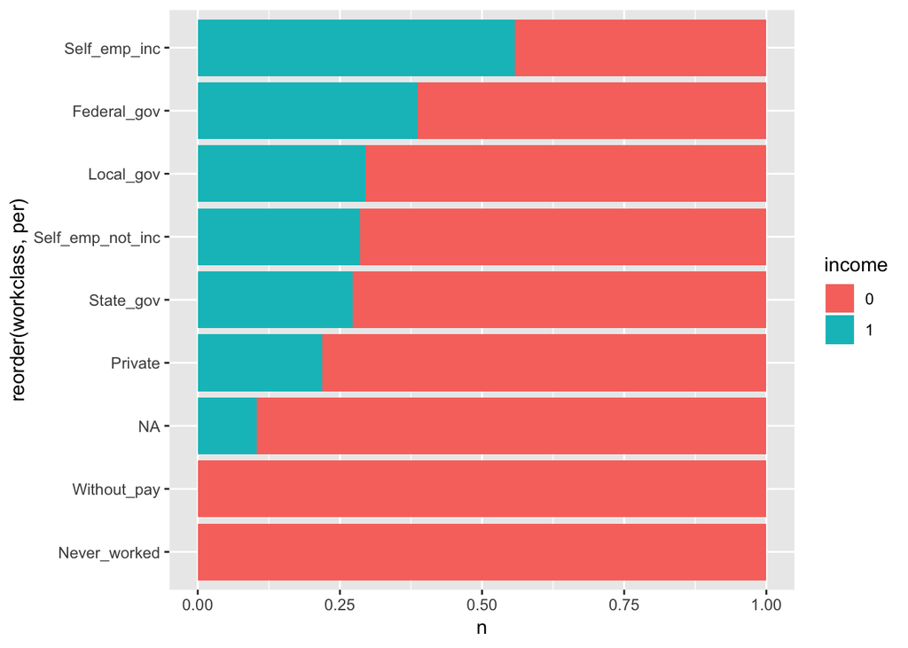

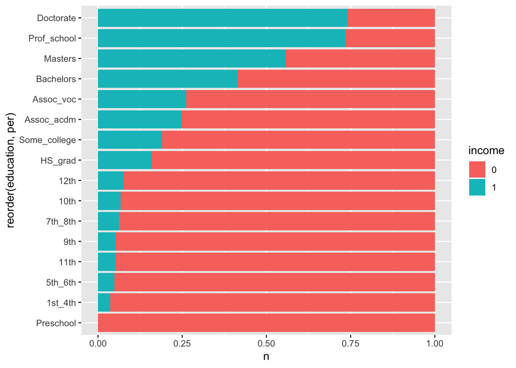

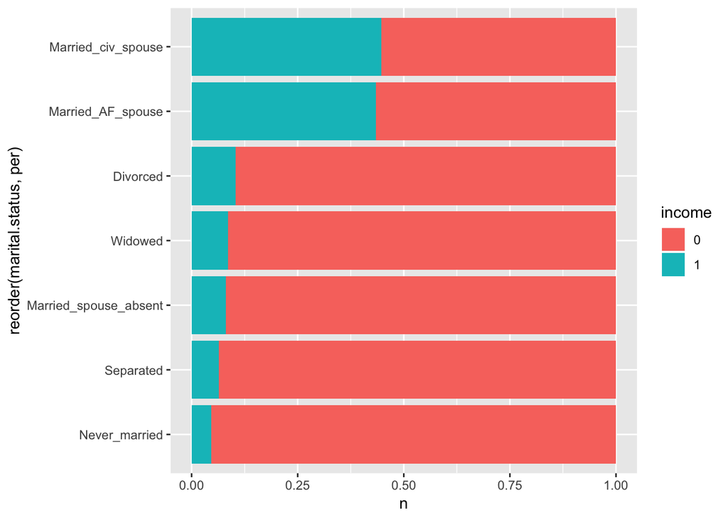

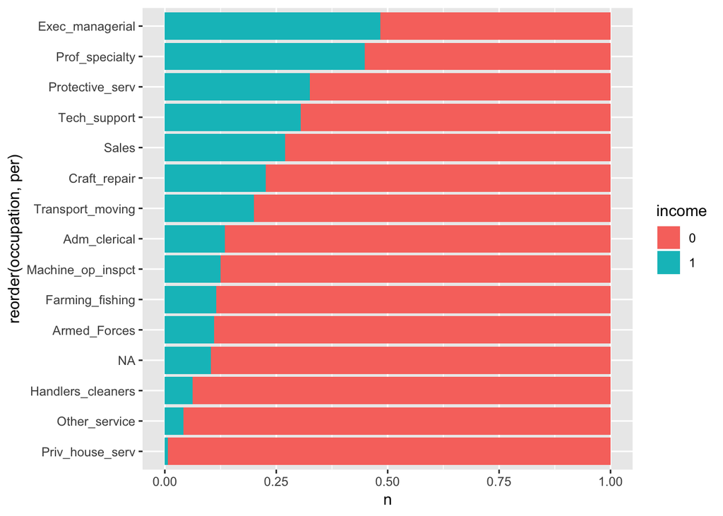

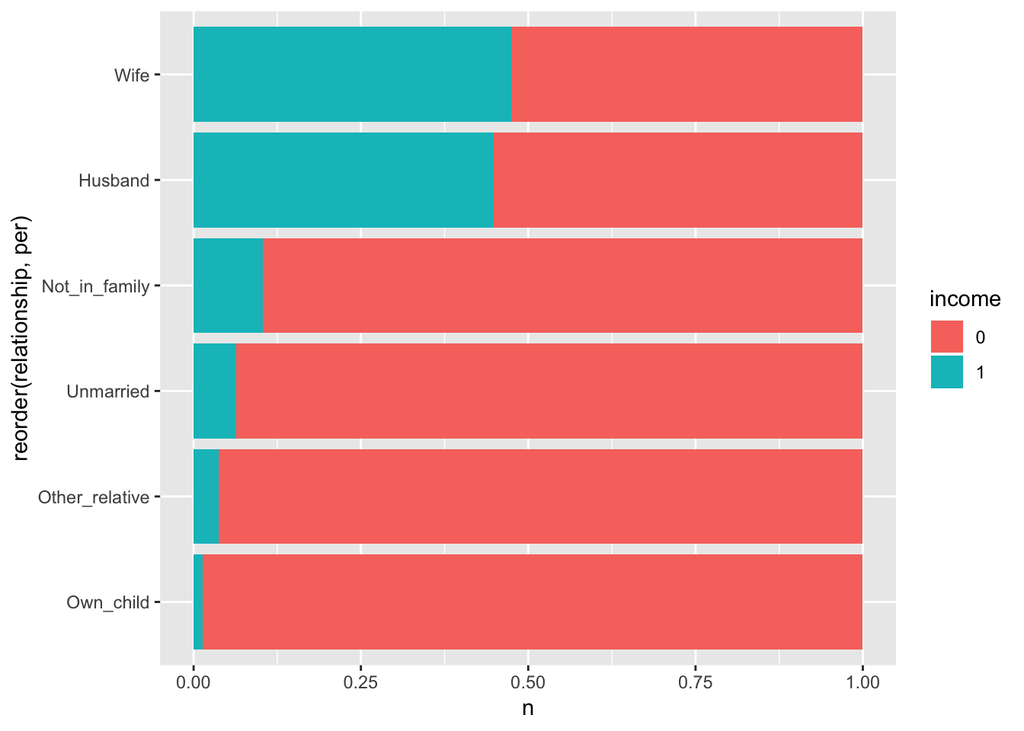

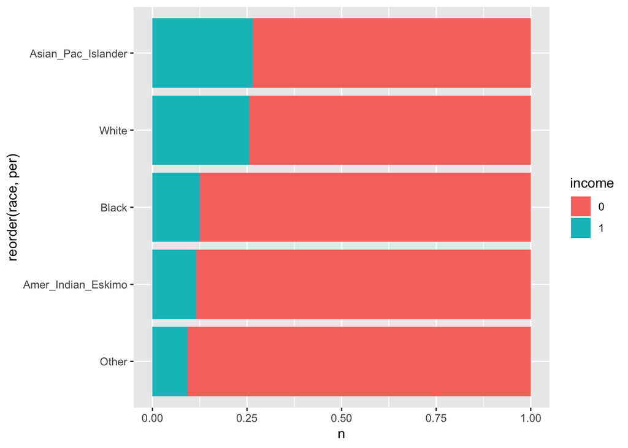

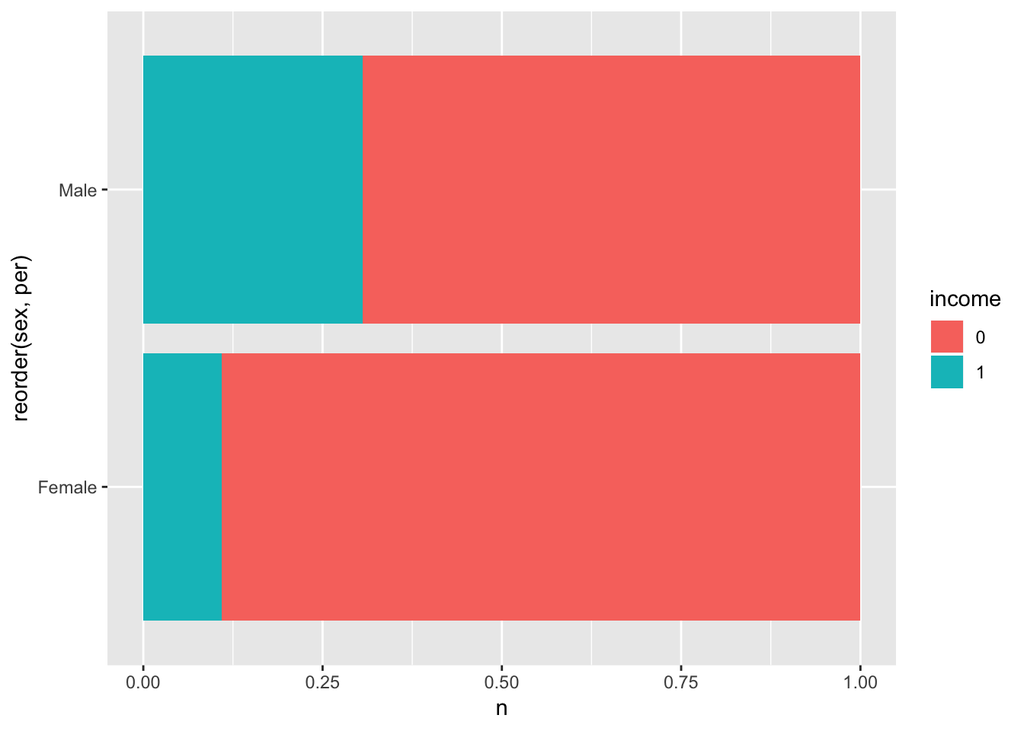

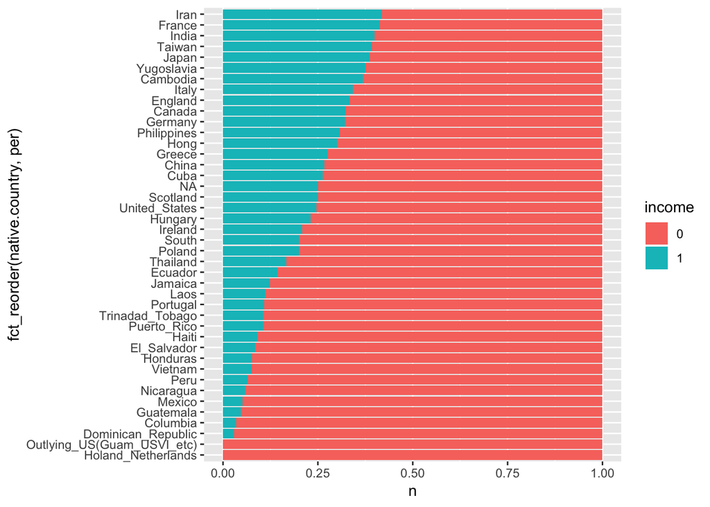

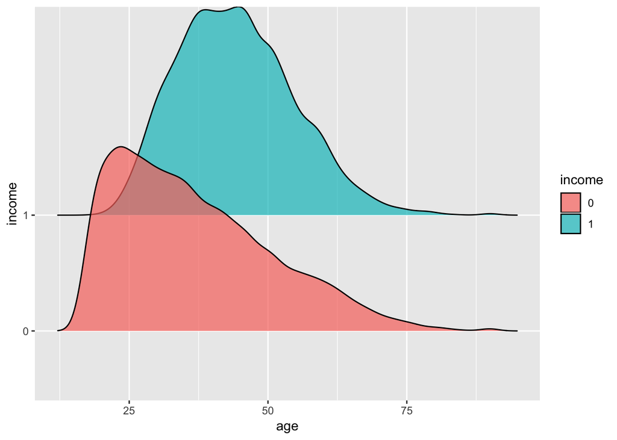

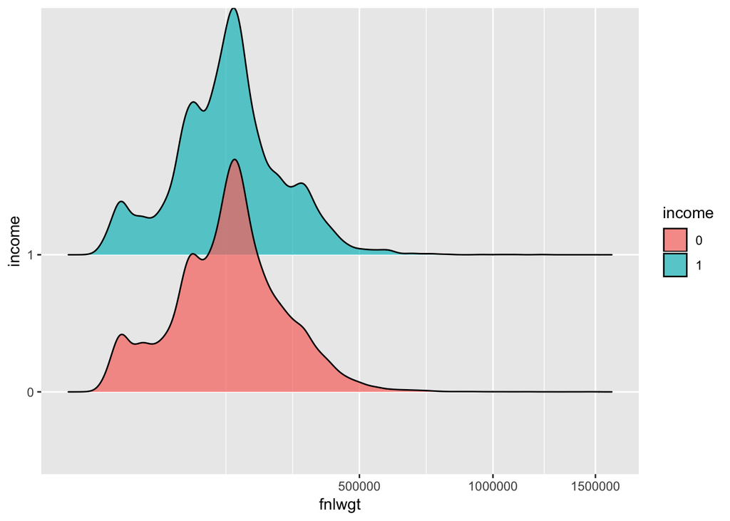

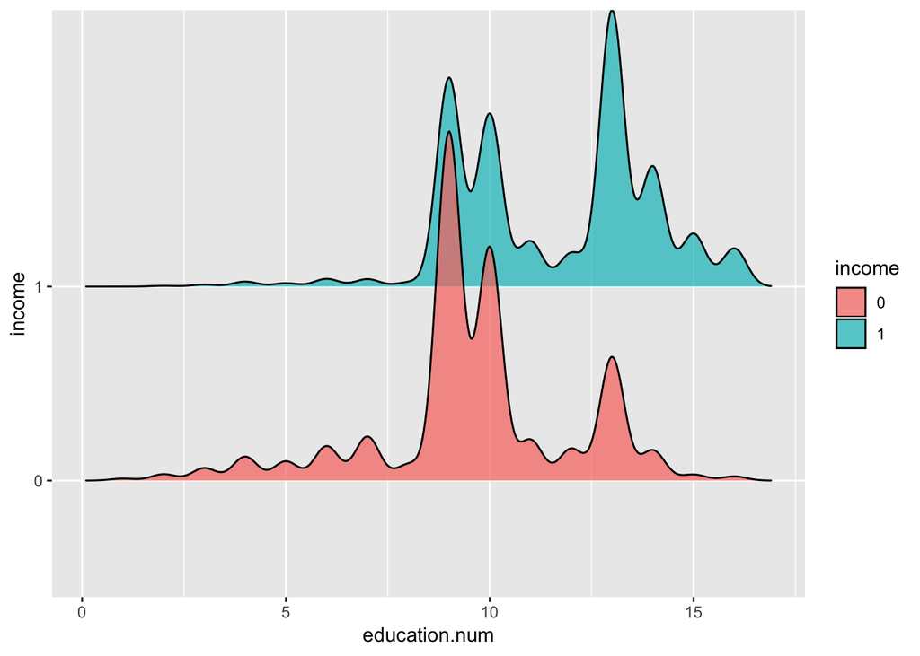

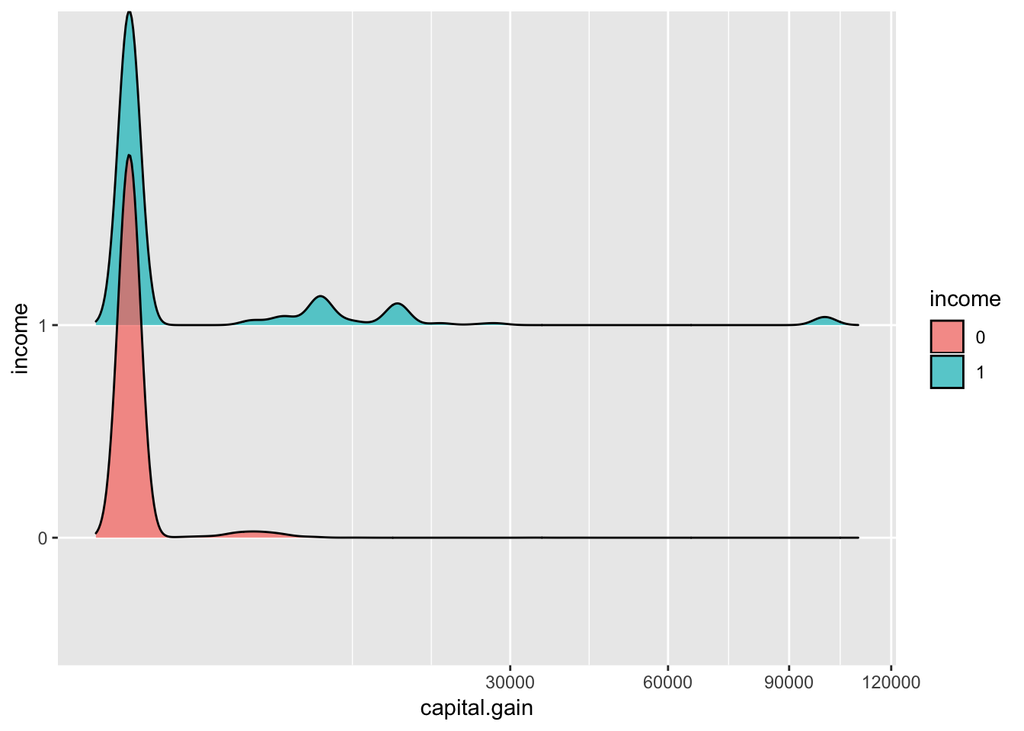

[2 more figures not shown]

The capital gain could be divided into categories.

##### Create scatter plots of the relationship between education and education num.

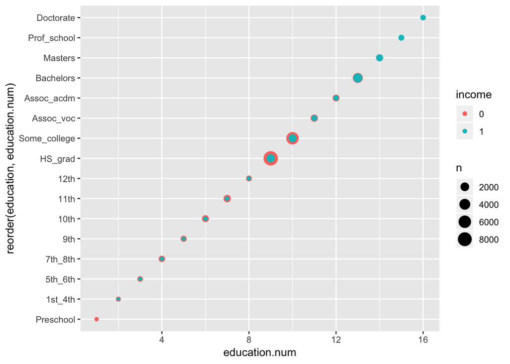

```r
adult%>%
  group_by(education, education.num, income) %>%
  summarize(n=n()) %>%
  arrange(education.num) %>%
  ggplot(aes(x = education.num, y = reorder(education, education.num), color = income))+
  geom_point(aes(size = n))
```

Education was excluded from variables because education and education.num were in a linear relationship.

### Generate the train set and the test set

```r
# Education was excluded from variables.
adult <-
  adult %>%
  select(-education)

# Test set will be 10% of adult data.
set.seed(1)
test_index <- createDataPartition(y = adult$income, times = 1, p = 0.1, list = FALSE)
train <- adult[-test_index,]
test <- adult[test_index,]
```

### Comparison of CART and Random Forests

#### CART

CART used rpart and partykit package.

```r
set.seed(1)
fit_rpart <- rpart(income ~ ., data = train)
plot(as.party(fit_rpart))

yhat_rpart = factor(predict(fit_rpart, test, type = "class"), levels = levels(test$income))

confusionMatrix(yhat_rpart,test$income)
```

#### Random Forests

Random Forests used the randomForest package.

```r
set.seed(1)
fit_rf <- randomForest(income ~ ., data = train)
fit_rf
varImpPlot(fit_rf)

yhat_rf = factor(predict(fit_rf, test), levels = levels(test$income))

confusionMatrix(yhat_rf, test$income)
```

## Results section

### CART

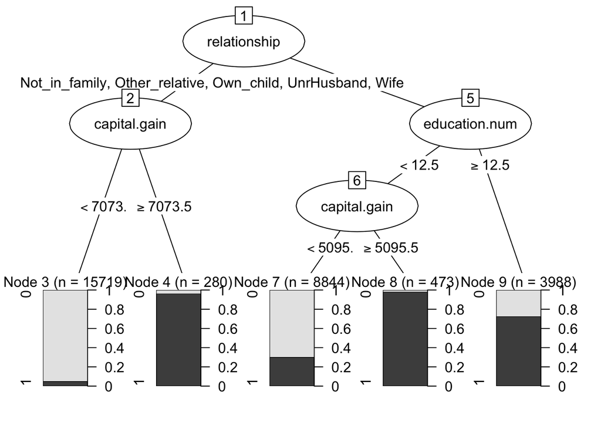

```r
set.seed(1)
fit_rpart <- rpart(income ~ ., data = train)
plot(as.party(fit_rpart))
```

```r
yhat_rpart = factor(predict(fit_rpart, test, type = "class"), levels = levels(test$income))

confusionMatrix(yhat_rpart,test$income)
```

```
## Confusion Matrix and Statistics
##
##           Reference
## Prediction    0    1
##          0 2340  386
##          1  132  399
##
##                Accuracy : 0.841
##                  95% CI : (0.8279, 0.8534)
##     No Information Rate : 0.759
##     P-Value [Acc > NIR] : < 2.2e-16
##
##                   Kappa : 0.5113
##  Mcnemar's Test P-Value : < 2.2e-16
##
##             Sensitivity : 0.9466
##             Specificity : 0.5083
##          Pos Pred Value : 0.8584
##          Neg Pred Value : 0.7514
##              Prevalence : 0.7590
##          Detection Rate : 0.7185
##    Detection Prevalence : 0.8370
##       Balanced Accuracy : 0.7274
##
##        'Positive' Class : 0
##
```

### Random Forests

```r
set.seed(1)
fit_rf <- randomForest(income ~ ., data = train)
fit_rf
```

```
##
## Call:
##  randomForest(formula = income ~ ., data = train)
##                Type of random forest: classification
##                      Number of trees: 500
## No. of variables tried at each split: 3
##
##         OOB estimate of  error rate: 13.37%
## Confusion matrix:
##       0    1 class.error
## 0 20842 1406  0.06319669
## 1  2512 4544  0.35600907
```

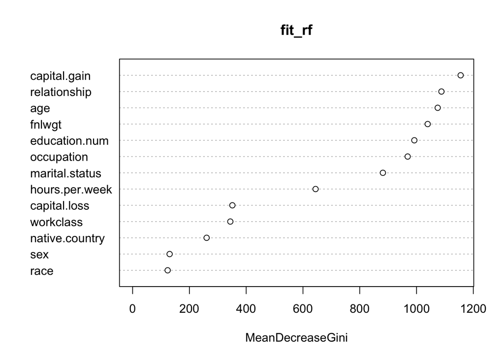

```r
varImpPlot(fit_rf)
```

```r
yhat_rf = factor(predict(fit_rf, test), levels = levels(test$income))

confusionMatrix(yhat_rf, test$income)
```

```
## Confusion Matrix and Statistics
##
##           Reference
## Prediction    0    1
##          0 2308  268
##          1  164  517
##
##                Accuracy : 0.8674
##                  95% CI : (0.8552, 0.8788)
##     No Information Rate : 0.759
##     P-Value [Acc > NIR] : < 2.2e-16
##
##                   Kappa : 0.6203
##  Mcnemar's Test P-Value : 7.211e-07
##
##             Sensitivity : 0.9337
##             Specificity : 0.6586
##          Pos Pred Value : 0.8960
##          Neg Pred Value : 0.7592
##              Prevalence : 0.7590
##          Detection Rate : 0.7086
##    Detection Prevalence : 0.7909
##       Balanced Accuracy : 0.7961
##
##        'Positive' Class : 0
##
```

## Conclusion section

### Why CART and Random Forests

This data set contains both numerical data and categorical data, so we selected a method that can support both.

In this case, Random Forests is more accurate, but CART is more interpretable.

### Results

In CART, relationship, capital gain and education number were selected.

```r
set.seed(1)
fit_rpart <- rpart(income ~ ., data = train)
yhat_rpart = factor(predict(fit_rpart, test, type = "class"), levels = levels(test$income))
con_rpart <- confusionMatrix(yhat_rpart,test$income)

set.seed(1)
fit_rf <- randomForest(income ~ ., data = train)
yhat_rf = factor(predict(fit_rf, test), levels = levels(test$income))
con_rf <- confusionMatrix(yhat_rf, test$income)

tibble(method = c("CART", "Random Forests"),
       accuracy = c(con_rpart[["overall"]][["Accuracy"]], con_rf[["overall"]][["Accuracy"]]),
       Sensitivity = c(con_rpart[["byClass"]][["Sensitivity"]],con_rf[["byClass"]][["Sensitivity"]]),
       Specificity = c(con_rpart[["byClass"]][["Specificity"]],con_rf[["byClass"]][["Specificity"]])) %>%
  knitr::kable()
```

| method | accuracy | Sensitivity | Specificity |
| --- | --- | --- | --- |
| CART | 0.8409579 | 0.9466019 | 0.5082803 |
| Random Forests | 0.8673626 | 0.9336570 | 0.6585987 |